# Ajuste por inflación

Santiago Rossi

21/10/2019

# ¿Qué entendemos por inflación?

La inflación es un **incremento sostenido del nivel general de precios** de los bienes y servicios de una economía

## Formas de medir el nivel general de precios

**1) Deflactor del PIB**: El deflactor del PIB ($DPIB$) es un índice que mide el precio medio de los bienes y servicios producidos en un año de referencia.

$$DPIB_t = \frac{\sum^N_{i=1}{p^i_t.q^i_t}}{\sum^N_{i=1}p^i_0.q^i_t}*100 = \frac{\text{PIB a precios corriente}}{\text{PIB a precios de año base}}$$
Con

- $q^i_t$ la cantidad del bien i en el período t
- $p^i_t$ precio del bien i en el período t
- $p^i_0$ el precio del bien i en el período de referencia (en Argentina es 2004 actualmente)

**2) Inflación medida por el IPC**: El índice de precios al consumidor (IPC) mide el costo de una canasta de bienes y servicios que los hogares suelen comprar en un período de referencia
$$IPC_t = \frac{\sum^N_{i=1}{p^i_t.q^i_0}}{\sum^N_{i=1}p^i_0.q^i_0}*100 = \frac{\text{Canasta a precios corrientes}}{\text{Canasta a precios de período de referencia}}$$

**3) Otras menos conocidas** : El índice de precios al por mayor (IPM) o el índice de precios al productor (IPP)

## Cálculo de la inflación

$$\pi_t = 100*\frac{IPC_t - IPC_{t-1}}{IPC_{t-1}}$$

```r
ipc_historico<-read.csv("ipc_historico.csv",header = T,sep = ";",stringsAsFactors = F)
ipc_historico$indice_tiempo<-as.Date(ipc_historico$indice_tiempo,format = "%d/%m/%Y")
ipc_historico <- ipc_historico %>% mutate(inflacion_mensual = (ipc/lag(ipc) -1)*100,
                                          inflacion_anual = (ipc/lag(ipc,12) -1)*100)
summary(ipc_historico)
```

```
 indice_tiempo             ipc               salario           dolar        inflacion_mensual inflacion_anual
 Min.   :1943-01-01   Min.   :2.000e+00   Min.   : 14.08   Min.   : 1.000   Min.   : -6.072   Min.   :   -7.024
 1st Qu.:1962-02-15   1st Qu.:9.000e+01   1st Qu.: 14.89   1st Qu.: 1.000   1st Qu.:  0.451   1st Qu.:   11.983
 Median :1981-04-01   Median :1.985e+06   Median : 32.31   Median : 3.136   Median :  1.762   Median :   24.014
 Mean   :1981-04-01   Mean   :2.115e+14   Mean   :103.75   Mean   : 6.522   Mean   :  4.272   Mean   :  194.022
 3rd Qu.:2000-05-16   3rd Qu.:1.012e+14   3rd Qu.:121.47   3rd Qu.: 5.329   3rd Qu.:  4.622   3rd Qu.:   58.823
 Max.   :2019-07-01   Max.   :4.440e+15   Max.   :658.29   Max.   :57.905   Max.   :196.634   Max.   :20262.873
 NA's   :4            NA's   :4           NA's   :623      NA's   :618      NA's   :5         NA's   :16
```

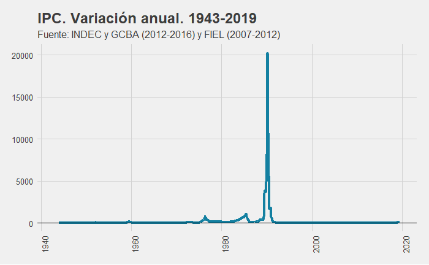

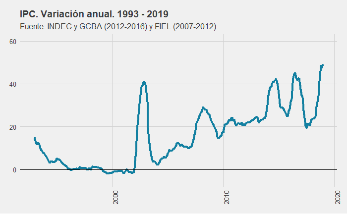